# Q-sort methodology proof of concept for Tom Lang

by Martin Brown, Martin.Brown@state.or.us, +1 503-229-5502

## Introduction

This R markdown notebook is a demonstration that a [“qsort” analysis](https://en.wikipedia.org/wiki/Q_methodology) is technically feasible here at Oregon DEQ. DEQ’s Tom Lang is interested in using q sorts to understand attitudes towards waste management and materials management in western Oregon counties.

I will try to:

- import some qsort field data which Tom Lang has entered via [PQMethod](http://schmolck.org/qmethod/) software
- utilize that data in a pre-programmed q sort, performed by the R package [qmethod](https://journal.r-project.org/archive/2014-2/zabala.pdf)
- display standard output (plots and data tables) produced by the q sort method.
- alter some of the standard output for better comprehension (e.g. by adding full statement labels)

In this session I will not attempt to understand or interpret the content of the q sorts.

## Setting up workspace

Loading required R packages…

```r
library(tidyverse)
library(qmethod)
library(knitr)
library(rmarkdown)
library(kableExtra)
```

```r
library(sjPlot)
#library(plotly)
```

## Importing sample data

```r
# here is the score data itself
my_better_scores <-
  import.pqmethod(
    file="source_data/Sort_2_T.dat"
  )
```

```
## -----------------------------------------------
## The dataset named:
##  2030 in Tillamook County
## with 16 Q-sorts and 28 statements, was extracted successfully from the file:
##  source_data/Sort_2_T.dat
## -----------------------------------------------
## Please inspect the dataset to confirm.
```

```r
# might be useful to save out the short statement names
# provided by PQMethod (e.g. "sta_1") as a vector.
# They're kinda mysterious but might be useful.
short_statement_names <- row.names(my_better_scores)

# here is the full text of each statement, as a 1-field
# data frame
my_better_statements <-
  read.delim(
    file="source_data/Sort_2_T.sta",
    header=FALSE,
    col.names = c("long_statement")
    )

# here is a data frame that combines the long and short
# statement names and can be used for checking if necessary
my_scores_and_statements <-
  bind_cols(
    data.frame(short_statement=short_statement_names),
    my_better_statements,
    my_better_scores
  )

# here i write out that "checking" data frame into
# a spreadsheet file for easier use by non-programmers
write.csv(
  my_scores_and_statements,
  "intermediate_output/field_data_reexported_for_checking.csv",
  row.names = FALSE
)

# here is a simple data frame that relates the short and
# long statement names
my_statement_key <-
  my_scores_and_statements %>% select(short_statement, long_statement)

# removing a few unnecessary objects
rm(my_better_statements, my_scores_and_statements)
```

## The imported data

```r
tab_df(my_better_scores)
```

| 1A | 2A | 3A | 4A | 5A | 6A | 7A | 8A | 9A | 10A | 11A | 12A | 13A | 14A | 15A | 16A |
| --- | --- | --- | --- | --- | --- | --- | --- | --- | --- | --- | --- | --- | --- | --- | --- |
| -1 | -3 | -3 | 2 | -4 | 2 | -1 | 2 | 0 | 2 | 0 | -2 | -4 | 1 | 3 | -1 |
| 1 | 0 | -2 | 3 | 2 | 2 | -1 | 3 | 2 | -1 | 1 | -2 | -1 | 4 | 2 | -1 |
| -2 | -4 | -3 | 1 | -2 | 0 | -1 | -3 | -1 | 3 | 0 | -3 | -3 | -3 | 0 | -1 |
| 1 | -2 | -3 | 2 | -2 | 0 | -1 | -4 | -4 | 1 | 0 | -4 | -4 | -1 | 1 | -1 |
| 1 | 2 | -4 | 0 | 2 | 4 | -2 | -1 | 1 | 2 | 1 | 3 | -2 | 1 | 4 | 3 |
| 0 | 0 | 3 | 4 | 3 | 3 | 2 | -2 | 0 | -1 | 4 | 2 | -3 | 0 | -3 | -3 |
| 2 | -1 | 1 | 0 | 1 | -1 | 1 | -1 | -2 | -4 | -3 | 0 | 0 | 0 | 0 | 0 |
| 3 | 1 | 3 | -1 | 2 | 1 | -3 | -3 | -3 | 3 | -2 | -1 | 1 | 1 | 1 | -4 |
| 0 | 0 | 2 | 4 | -1 | 1 | 1 | 2 | 0 | 1 | 4 | 3 | 2 | 3 | 2 | 4 |
| 0 | 2 | 2 | -1 | 0 | 1 | -4 | -4 | -2 | 4 | 3 | 2 | 3 | 4 | -3 | -4 |
| 0 | 4 | 1 | -3 | 1 | 0 | -2 | 0 | -2 | -1 | -2 | 1 | -1 | 0 | 4 | 0 |
| -2 | 3 | -2 | -3 | -1 | 2 | 2 | 1 | 3 | 1 | 3 | -1 | -1 | -3 | -1 | 2 |
| -1 | -1 | -1 | -3 | -2 | -2 | -3 | 0 | 1 | -2 | -1 | -3 | -1 | -2 | 2 | -2 |
| -4 | 1 | -1 | 0 | -3 | -1 | 2 | -2 | 2 | -3 | 2 | 0 | 2 | -2 | -2 | -2 |
| -3 | -2 | -2 | 1 | -3 | -3 | 1 | 2 | -4 | 0 | -1 | 0 | -2 | -3 | 1 | 2 |
| -1 | 4 | 4 | 3 | 4 | -2 | 3 | -1 | -1 | -3 | 2 | -1 | 3 | -1 | 3 | 1 |
| -3 | 1 | -1 | -1 | -1 | -3 | -3 | -2 | 2 | -2 | -3 | -4 | -2 | -4 | 0 | -2 |
| -3 | -3 | 3 | -4 | 3 | 3 | 3 | -1 | 4 | -2 | 1 | 2 | -3 | 2 | -4 | 2 |
| -2 | 3 | 4 | -1 | 4 | 4 | 4 | 0 | 3 | -1 | 2 | 4 | 4 | -1 | -1 | 1 |
| -1 | -2 | 2 | -4 | 3 | 1 | 3 | 3 | 4 | 0 | 3 | 0 | 1 | 2 | -4 | 1 |
| 1 | 1 | -1 | -2 | -3 | -3 | -4 | 0 | 3 | 0 | 0 | -3 | 2 | -4 | -2 | 1 |
| 4 | -3 | 0 | 3 | 0 | -4 | 1 | 4 | 1 | 4 | -3 | 4 | 4 | 1 | 0 | 4 |
| -4 | -1 | -4 | 0 | -4 | -4 | 0 | 3 | -1 | 1 | -4 | 3 | 3 | -2 | -1 | 3 |
| 3 | -1 | 0 | -2 | -1 | 3 | 4 | 1 | 1 | 2 | -2 | -2 | 1 | 3 | -1 | -3 |
| 2 | 0 | 1 | 1 | 1 | -1 | 0 | -3 | -3 | -3 | -1 | 1 | 0 | 0 | -3 | -3 |
| 4 | 3 | 1 | 1 | 1 | 0 | 0 | 4 | -3 | -4 | -1 | 1 | 0 | 3 | 3 | 0 |
| 2 | 2 | 0 | 2 | 0 | -1 | -2 | 1 | 0 | 0 | -4 | -1 | 0 | 2 | 1 | 0 |
| 3 | -4 | 0 | -2 | 0 | -2 | 0 | 1 | -1 | 3 | 1 | 1 | 1 | -1 | -2 | 3 |

```r
tab_df(my_statement_key)
```

| short_statement | long_statement |
| --- | --- |
| sta_1 | Paper Recycling |
| sta_2 | Plastic Recycling |
| sta_3 | Metal Recycling |
| sta_4 | Glass Recycling |
| sta_5 | Extended Producer Responsibility Programs (i.e. PaintCare and E-Cycles) |
| sta_6 | Residential Curbside Recycling Service |
| sta_7 | Education programs to reduce contamination in the recycling stream |
| sta_8 | Residential Collection Service of Organics (yard debris & food scraps) |
| sta_9 | Commercial Recycling Services (industry, retailers, institutions) |
| sta_10 | Commercial Food Scraps Collection ( industry, retailers, institutions) |
| sta_11 | Community programs which promote education and volunteerism in recycling efforts (i.e. Master Recyclers) |
| sta_12 | Proper Disposal of Household Hazardous Waste |
| sta_13 | Proper Disposal of Pharmaceutical Waste |
| sta_14 | Prevention and Enforcement of Illegal Dumping |
| sta_15 | Proper Disposal of Asbestos |
| sta_16 | Disaster Debris Planning & Management |
| sta_17 | Proper Disposal of Sharps and Infectious Waste |
| sta_18 | Residential Collection of Solid Waste |
| sta_19 | Transfer Station Capacity |
| sta_20 | Commercial & Industrial Collection of Solid Waste |
| sta_21 | Proper Disposal of Bulky Waste |
| sta_22 | Industry standards which minimize the use of toxic chemicals in consumer products and packaging |
| sta_23 | Government procurement plans which prioritize products and services with low impacts to human health and the environmental |
| sta_24 | Reuse and repair programs which extend the lifespan of materials |
| sta_25 | Education for households and businesses which prevent the wasting of food |
| sta_26 | K-12 education curriculums on waste prevention and resource conservation |
| sta_27 | Consumer education programs to reduce the use and spread of toxic chemicals |
| sta_28 | Strategies to increase the salvage of non-hazardous building materials for reuse |

## Running an analysis

For simplicity I will run this asking for only 2 factors.

```r
my_analysis <-
  qmethod(dataset=my_better_scores, nfactors = 2)
```

```
## Q-method analysis.
## Finished on:             Mon Jan 27 16:54:16 2020
## Original data:           28 statements, 16 Q-sorts
## Forced distribution:     TRUE
## Number of factors:       2
## Rotation:                varimax
## Flagging:                automatic
## Correlation coefficient: pearson
```

## Standard outputs

At this point the R object “my_analysis” is storing the results. R can output this in various ways.

A summary statement…

```r
summary(my_analysis)
```

```
## Q-method analysis.
## Finished on:             Mon Jan 27 16:54:16 2020
## Original data:           28 statements, 16 Q-sorts
## Forced distribution:     TRUE
## Number of factors:       2
## Rotation:                varimax
## Flagging:                automatic
## Correlation coefficient: pearson
##
## Factor scores
##        fsc_f1 fsc_f2
## sta_1      -3     -2
## sta_2       1      0
## sta_3      -3     -3
## sta_4      -2     -4
## sta_5       1      1
## sta_6       4     -1
## sta_7       0      0
## sta_8       2     -3
## sta_9       2      3
## sta_10      2     -2
## sta_11      1     -1
## sta_12      0      2
## sta_13     -2     -3
## sta_14     -1      0
## sta_15     -4      1
## sta_16      3      1
## sta_17     -2     -4
## sta_18      3      2
## sta_19      4      4
## sta_20      3      3
## sta_21     -3     -1
## sta_22     -1      4
## sta_23     -4      3
## sta_24      0      0
## sta_25      0     -2
## sta_26      1      1
## sta_27     -1     -1
## sta_28     -1      2
##                                     f1    f2
## Average reliability coefficient   0.80  0.80
## Number of loading Q-sorts         6.00  6.00
## Eigenvalues                       2.95  2.80
## Percentage of explained variance 18.46 17.52
## Composite reliability             0.96  0.96
## Standard error of factor scores   0.20  0.20
```

A standard plot..

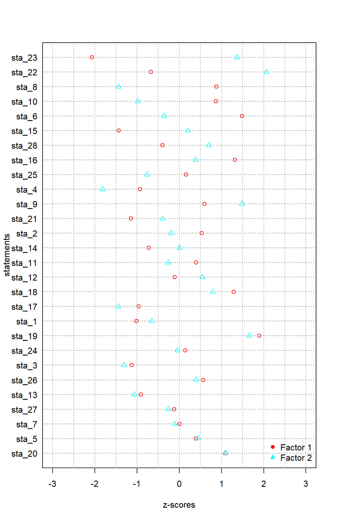

```r
plot(my_analysis)
```

A standard printout… (may be long)

```r
print(my_analysis)
```

```
## Q-method analysis.
## Finished on:             Mon Jan 27 16:54:16 2020
## Original data:           28 statements, 16 Q-sorts
## Forced distribution:     TRUE
## Number of factors:       2
## Rotation:                varimax
## Flagging:                automatic
## Correlation coefficient: pearson
##
## Original data :
##        1A 2A 3A 4A 5A 6A 7A 8A 9A 10A
## sta_1  -1 -3 -3  2 -4  2 -1  2  0   2
## sta_2   1  0 -2  3  2  2 -1  3  2  -1
## sta_3  -2 -4 -3  1 -2  0 -1 -3 -1   3
## sta_4   1 -2 -3  2 -2  0 -1 -4 -4   1
## sta_5   1  2 -4  0  2  4 -2 -1  1   2
## sta_6   0  0  3  4  3  3  2 -2  0  -1
## sta_7   2 -1  1  0  1 -1  1 -1 -2  -4
## sta_8   3  1  3 -1  2  1 -3 -3 -3   3
## sta_9   0  0  2  4 -1  1  1  2  0   1
## sta_10  0  2  2 -1  0  1 -4 -4 -2   4
##  (...) See item '...$dataset' for the full data.
##
## Q-sort factor loadings :
##         f1     f2
## 1A   0.176 -0.038
## 2A   0.447 -0.028
## 3A   0.752  0.315
## 4A  -0.039 -0.041
## 5A   0.788  0.320
## 6A   0.677  0.095
## 7A   0.244  0.643
## 8A  -0.418  0.639
## 9A   0.073  0.471
## 10A -0.262  0.050
##  (...) See item '...$loa' for the full data.
##
## Flagged Q-sorts :
##     flag_f1 flag_f2
## 1A  "FALSE" "FALSE"
```

[output cut: 53 more lines]

```
## f2 0.28 0.28
##
## Distinguishing and consensus statements :
##         dist.and.cons  f1_f2 sig_f1_f2
## sta_1       Consensus -0.359
## sta_2  Distinguishing  0.727         *
## sta_3       Consensus  0.176
## sta_4  Distinguishing  0.887        **
## sta_5       Consensus -0.058
## sta_6  Distinguishing  1.849      ****
## sta_7       Consensus  0.121
## sta_8  Distinguishing  2.322      ****
## sta_9  Distinguishing -0.887        **
## sta_10 Distinguishing  1.852      ****
##  (...) See item '...$qdc' for the full data.
```

## Some attempt at customizing output

Here I will draw out the z-scores for each factor, label them with the long statement names.

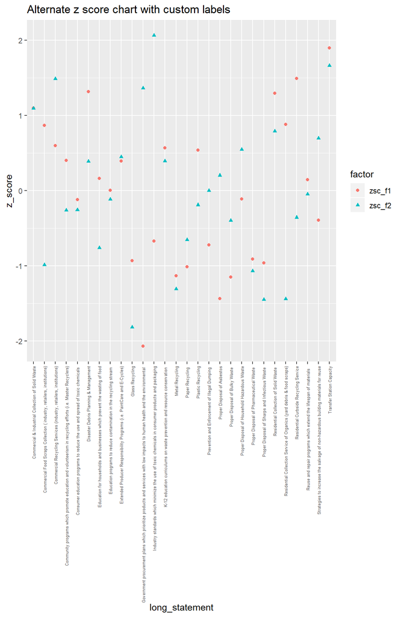

```r
my_own_plot_data <-
  my_analysis$zsc
short_statement <- row.names(my_own_plot_data)
my_own_plot_data_2 <-
  bind_cols(
    data.frame(short_statement=short_statement),
    my_own_plot_data
  )
my_own_plot_data_3 <-
  full_join(
    my_own_plot_data_2,
    my_statement_key,
    by="short_statement"
  )
my_own_plot_data_4 <-
  pivot_longer(
    data=my_own_plot_data_3,
    names_to = "factor",
    values_to = "z_score",
    zsc_f1:zsc_f2
  )
ggplot()+
  ggtitle("Alternate z score chart with custom labels")+
  geom_point(
    data=my_own_plot_data_4,
    aes(y=z_score, x=long_statement, color=factor, shape=factor)
  )+
  theme(
    axis.text.x=element_text(size=5, angle=90, hjust=1, vjust=0.5)
  )
```

Ok, I think I’ve shown we can produce output. Now, to make it mean something is the next task.